# [Memo - Deep Learning - Tensorflow](https://www.youtube.com/watch?v=Mubj_fqiAv8&list=PLeo1K3hjS3uu7CxAacxVndI4bE_o3BDtO&index=1)

## **Model Evaluate**

```python
model.evaluate(X_test_flattened, y_test)
```

```
[0.32147109508514404, 0.9143000245094299]
```

#### - **Prdediction**

```python
y_preds = model.predict(X_test_flattened)
```

```python
y_preds[0]
```

```
array([1.0158585e-02, 1.7649877e-04, 3.3006098e-02, 7.3862779e-01,
       5.6233473e-02, 1.8736912e-01, 1.5852131e-05, 9.9895340e-01,
       1.3272220e-01, 7.7970177e-01], dtype=float32)
```

```python
np.argmax(y_preds[0])
```

```
7
```

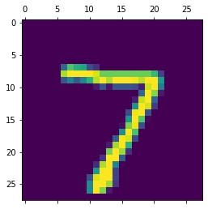

```python
plt.matshow(X_test[0])
```

```python
y_test[0]
```

```
7
```

```python
y_pred_labels = [np.argmax(y_pred) for y_pred in y_preds]
```

```python
y_pred_labels[:5]
```

```
[7, 2, 1, 0, 4]
```

```python
y_test[:5]
```

```
array([7, 2, 1, 0, 4], dtype=uint8)
```

```python
cm = tf.math.confusion_matrix(
    labels=y_test,
    predictions=y_pred_labels
)
cm
```

```
<tf.Tensor: shape=(10, 10), dtype=int32, numpy=
array([[ 955,    0,    2,    1,    0,    4,   14,    1,    3,    0],
       [   0, 1111,    2,    2,    0,    2,    4,    1,   13,    0],
       [   8,   12,  895,   23,   12,    1,   15,   21,   40,    5],
       [   3,    1,   20,  910,    0,   26,    5,   15,   19,   11],
       [   1,    2,    3,    1,  887,    1,   16,    2,    9,   60],
       [  10,    6,    1,   35,    9,  768,   18,   10,   24,   11],
       [   7,    3,    4,    1,    6,   14,  920,    1,    2,    0],
       [   2,   14,   21,    5,    7,    0,    2,  935,    3,   39],
       [   4,   11,   10,   24,    8,   28,   11,   14,  849,   15],
       [  10,    5,    4,   13,   25,    8,    0,   25,    6,  913]],
      dtype=int32)>
```

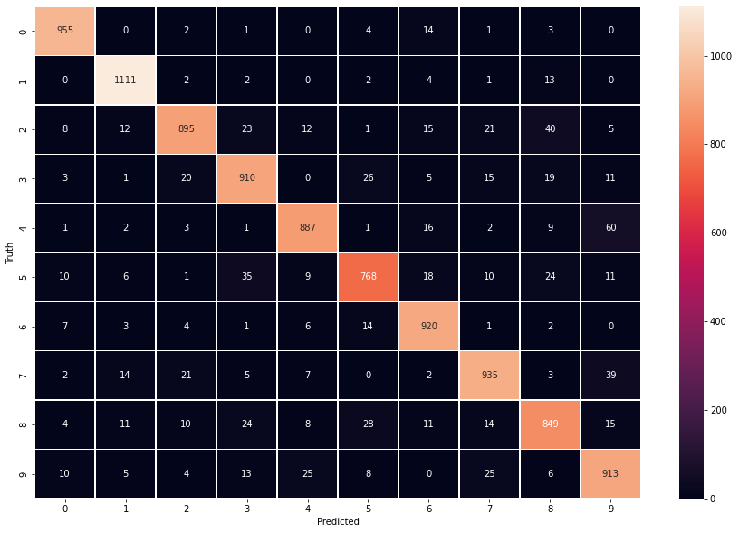

```python
plt.figure(figsize=(15, 10))
sn.heatmap(
    cm,
    annot=True,
    fmt="d",
    linewidth=0.5,
)
plt.xlabel("Predicted")
plt.ylabel("Truth")
```

#### - **Add Hidden Layer to Improve**

```python
model = keras.Sequential([
    keras.layers.Dense(100, input_shape=(784,), activation='relu'),
    keras.layers.Dense(10, activation='sigmoid'),
])

model.compile(
    optimizer='adam',
    loss='sparse_categorical_crossentropy',
    metrics=['accuracy']
)

model.fit(X_train_flattened, y_train, epochs=5)
```

```
<keras.callbacks.History at 0x7fc7bade8150>
```

```python
model.evaluate(X_test_flattened, y_test)
```

```
[0.08750998228788376, 0.9739999771118164]
```

```python
y_preds = model.predict(X_test_flattened)
```

```python
y_pred_labels = [np.argmax(y_pred) for y_pred in y_preds]
```

```python
cm = tf.math.confusion_matrix(
    labels=y_test,
    predictions=y_pred_labels
)
cm
```

```
<tf.Tensor: shape=(10, 10), dtype=int32, numpy=
array([[ 970,    0,    2,    1,    1,    0,    3,    1,    2,    0],
       [   0, 1111,    6,    2,    0,    1,    2,    5,    8,    0],
       [   4,    0, 1014,    2,    1,    0,    2,    6,    3,    0],
       [   1,    0,   14,  970,    0,   13,    0,    5,    4,    3],
       [   0,    0,    5,    1,  959,    1,    4,    4,    0,    8],
       [   3,    2,    0,    5,    2,  872,    4,    1,    2,    1],
       [   4,    3,    1,    1,    4,    5,  938,    0,    2,    0],
       [   2,    0,   10,    1,    0,    0,    0, 1013,    1,    1],
       [   9,    0,    6,    5,    5,    6,    1,    6,  933,    3],
       [   6,    2,    0,    5,    5,    6,    1,   16,    8,  960]],
      dtype=int32)>
```

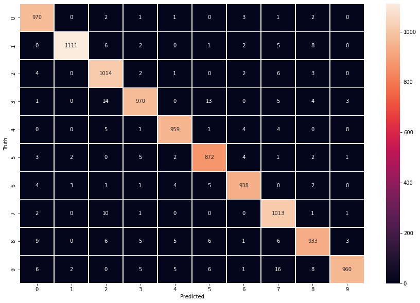

```python
plt.figure(figsize=(15, 10))
sn.heatmap(
    cm,
    annot=True,
    fmt="d",
    linewidth=0.5,
)
plt.xlabel("Predicted")
plt.ylabel("Truth")
```

#### - Integrate Faltten with Model

```python
model = keras.Sequential([
    keras.layers.Flatten(input_shape=(28,28)),
    keras.layers.Dense(100, activation='relu'),
    keras.layers.Dense(10, activation='sigmoid'),
])

model.compile(
    optimizer='adam',
    loss='sparse_categorical_crossentropy',
    metrics=['accuracy']
)

model.fit(X_train, y_train, epochs=5)
```

```
<keras.callbacks.History at 0x7fc7bab34090>
```

## **Model Improving Thinking**

[figure not shown]

#### **Optimizer**

[figure not shown]

#### **Loss / Cost Function**

[figure not shown]

### Regression Problems

#### Linear Regression

> - Create the data with known **parameters** (things that can be learned by a model)
> - Build model to estimate these parameters using [**gradient descent**](https://en.wikipedia.org/wiki/Gradient_descent).

## **Gradient Descent**

[figure not shown]

> - **RMSE**  
>   -> *np.sqrt(np.mean(np.square(targets - predictions)))*  
>   -> **`from sklearn.metrics import mean_squared_error`**  
>   -> *mean_squared_error(targets, predictions, squared=False)`*

[figure not shown]

> Geometrically, the residuals can be visualized as follows:

[figure not shown]

### Logistic Regression

[figure not shown]

### Classification Problems

> **`cross entropy loss function`**

[figure not shown]

> - MAE

```python
y_predicted = np.array([1, 1, 0, 0, 1])
y_true = np.array([0.3, 0.7, 1, 0, 0.5])
```

```python
def mae(y_true, y_predicted):
    total_error = 0
    for yt, yp in zip(y_true, y_predicted):
        total_error += abs(yt - yp)
    print("Total Error: ", total_error)
    mae = total_error / len(y_true)
    print("MAE: ", mae)
    return mae
```

```python
mae(y_true, y_predicted)
```

```
Total Error:  2.5
MAE:  0.5
```

```
0.5
```

> - Binary Cross Entropy

```python
epsilon = 1e-15
```

```python
np.log(epsilon)
```

```
-34.538776394910684
```

```python
y_predicted_new = [max(i, epsilon) for i in y_predicted]
y_predicted_new
```

```
[1, 1, 1e-15, 1e-15, 1]
```

```python
y_predicted_new = [min(i,1-epsilon) for i in y_predicted_new]
y_predicted_new
```

```
[0.999999999999999, 0.999999999999999, 1e-15, 1e-15, 0.999999999999999]
```

```python
np.log(y_predicted_new)
```

```
array([-9.99200722e-16, -9.99200722e-16, -3.45387764e+01, -3.45387764e+01,
       -9.99200722e-16])
```

```python
np.log(y_predicted)
```

```
array([  0.,   0., -inf, -inf,   0.])
```

```python
def log_loss(y_true, y_predicted):
    epsilon = 1e-15
    y_predicted_new = [max(i,epsilon) for i in y_predicted]
    y_predicted_new = [min(i,1-epsilon) for i in y_predicted_new]
    y_predicted_new = np.array(y_predicted_new)
    return -np.mean(y_true*np.log(y_predicted_new)+(1-y_true)*np.log(1-y_predicted_new))
```

```python
def sigmoid_numpy(X):
   return 1/(1+np.exp(-X))

sigmoid_numpy(np.array([12,0,1]))
```

```
array([0.99999386, 0.5       , 0.73105858])
```

- Neural Network

```python
class myNN:
    def __init__(self):
        self.w1 = 1
        self.w2 = 1
        self.bias = 0

    def fit(self, X, y, epochs, loss_thresold):
        self.w1, self.w2, self.bias = self.gradient_descent(X ,y, epochs, loss_thresold)
        print(f"Final weights and bias: w1: {self.w1}, w2: {self.w2}, bias: {self.bias}")

    def predict(self, X):
        weighted_sum = self.w1*X['age'] + self.w2*X['affordability'] + self.bias
        return 1/(1+np.exp(-weighted_sum)) # sigmoid

    def gradient_descent(self, X, y, epochs, loss_thresold):
        w1=w2=1
        bias=0
        rate=0.5
        n = len(X['age'])
        for i in range(epochs):
            weighted_sum = w1 * X['age'] + w2 * X['affordability'] + bias
            y_predicted = 1/(1+np.exp(-weighted_sum)) # sigmoid
            loss = log_loss(y, y_predicted)

            w1d = (1/n)*np.dot(np.transpose(X['age']),(y_predicted-y))
            w2d = (1/n)*np.dot(np.transpose(X['affordability']),(y_predicted-y))
            bias_d = np.mean(y_predicted-y)

            w1 = w1 - rate * w1d
            w2 = w2 - rate * w2d
            bias = bias - rate * bias_d

            if i%50==0:
                print (f'Epoch:{i}, w1:{w1}, w2:{w2}, bias:{bias}, loss:{loss}')

            if loss<=loss_thresold:
                print (f'Epoch:{i}, w1:{w1}, w2:{w2}, bias:{bias}, loss:{loss}')
                break

        return self.w1, self.w2, self.bias
```

```python
def gradient_descent(age, affordability, y_true, epochs):
    w1 = 1,
    w2 = 1,
    bias = 0,
    learning_rate = 0.5,
    n = len(age)

    for i in range(epochs):
        weight_sum = w1 * age + w2 * affordability + bias
        y_predicted = sigmoid_numpy(weight_sum)

        loss = log_loss(y_true, y_predicted)

        w1_d = (1/n)*np.dot(np.transpose(age), (y_predicted - y_true))
        w2_d = (1/n)*np.dot(np.transpose(affordability), (y_predicted - y_true))
        bias_d = np.mean(y_predicted - y_true)

        w1 = w1 - learning_rate * w1_d
        w2 = w2 - learning_rate * w2_d
        bias = bias - learning_rate * bias_d

        print(f"Epoch-{i}: , w1: {w1}, w2: {w2}, bias: {bias}, loss: {loss}")

    return w1, w2, bias
```

```python
def gradient_descent(age, affordability, y_true, epochs, loss_thresold):
    w1 = w2 = 1
    bias = 0
    learning_rate = 0.5
    n = len(age)
    for i in range(epochs):
        weighted_sum = w1 * age + w2 * affordability + bias
        y_predicted = sigmoid_numpy(weighted_sum)
        loss = log_loss(y_true, y_predicted)

        w1d = (1/n)*np.dot(np.transpose(age),(y_predicted-y_true))
        w2d = (1/n)*np.dot(np.transpose(affordability),(y_predicted-y_true))
        bias_d = np.mean(y_predicted-y_true)

        w1 = w1 - learning_rate * w1d
        w2 = w2 - learning_rate * w2d
        bias = bias - learning_rate * bias_d

        print (f'Epoch:{i}, w1:{w1}, w2:{w2}, bias:{bias}, loss:{loss}')

        if loss<=loss_thresold:
            break

    return w1, w2, bias
```

> - Batch Gradient Descent

```python
def batch_gradient_descent(X, y, epochs, learning_rate=0.01):
    number_of_features = X.shape[1]
    w = np.ones(shape=number_of_features)
    bias = 0
    total_sample = X.shape[0]

    epoch_list = []
    cost_list = []

    for i in range(epochs):
        y_predicted = np.dot(w, X.T) + bias

    w_grad = -(2/total_sample)*X.T.dot(y-y_predicted)
    b_grad = -(2/total_sample)*np.sum(y-y_predicted)

    w = w - learning_rate * w_grad
    bias = bias - learning_rate * b_grad

    cost = np.mean(np.square(y-y_predicted))

    if i%10==0:
        epoch_list.append(i)
        cost_list.append(cost)

    return w, bias, cost, cost_list, epoch_list
```

> - Stochastic Gradient Descent

```python
def stochastic_gradient_descent(X, y_true, epochs, learning_rate = 0.01):

    number_of_features = X.shape[1]
    # numpy array with 1 row and columns equal to number of features. In
    # our case number_of_features = 3 (area, bedroom and age)
    w = np.ones(shape=(number_of_features))
    b = 0
    total_samples = X.shape[0]

    cost_list = []
    epoch_list = []

    for i in range(epochs):
        random_index = random.randint(0,total_samples-1) # random index from total samples
        sample_x = X[random_index]
        sample_y = y_true[random_index]

        y_predicted = np.dot(w, sample_x.T) + b

        w_grad = -(2/total_samples)*(sample_x.T.dot(sample_y-y_predicted))
        b_grad = -(2/total_samples)*(sample_y-y_predicted)

        w = w - learning_rate * w_grad
        b = b - learning_rate * b_grad

        cost = np.square(sample_y-y_predicted)

        if i%100==0: # at every 100th iteration record the cost and epoch value
            cost_list.append(cost)
            epoch_list.append(i)

    return w, b, cost, cost_list, epoch_list
```

> - Chain Rule

[figure not shown]

## Matrix Basic

```python
revenue = np.array([[180, 200, 220], [24, 36, 40], [12, 18, 20]])
expense = np.array([[80, 90, 100], [10, 16, 20], [8, 10, 10]])

profit = revenue - expense

profit
```

```
array([[100, 110, 120],
       [ 14,  20,  20],
       [  4,   8,  10]])
```

```python
price_per_unit = np.array([1000, 400, 1200])
unit = np.array([[30, 40, 50], [5, 10, 15], [2, 5, 7]])
```

```python
price_per_unit
```

```
array([1000,  400, 1200])
```

```python
unit
```

```
array([[30, 40, 50],
       [ 5, 10, 15],
       [ 2,  5,  7]])
```

```python
np.dot(price_per_unit, unit)
```

```
array([34400, 50000, 64400])
```

# Project 2 - Aritifical Neural Network for Image Classifieration

> [The CIFAR-10 dataset](https://www.cs.toronto.edu/~kriz/cifar.html)

[figure not shown]

## **Get Data**

> [The CIFAR-10 dataset](https://www.cs.toronto.edu/~kriz/cifar.html)

[figure not shown]

```python
(X_train, y_train), (X_test, y_test) =  keras.datasets.cifar10.load_data()
```

```
Downloading data from https://www.cs.toronto.edu/~kriz/cifar-10-python.tar.gz
```

## **Exploratory Data**

```python
X_train.shape
```

```
(50000, 32, 32, 3)
```

```python
y_train.shape
```

```
(50000, 1)
```

```python
X_test.shape
```

```
(10000, 32, 32, 3)
```

```python
y_test.shape
```

```
(10000, 1)
```

```python
classes = ["airplane","automobile","bird","cat","deer","dog","frog","horse","ship","truck"]

def plot_sample(index):
    plt.figure(figsize = (1,1))
    plt.imshow(X_train[index])
```

```python
y_train[:10]
```

```
array([[6],
       [9],
       [9],
       [4],
       [1],
       [1],
       [2],
       [7],
       [8],
       [3]], dtype=uint8)
```

```python
plot_sample(0)
```

[output not shown]

```python
plot_sample(1)
```

[output not shown]

### **Preprocess Data**

> - Scaling

```python
X_train_scaled = X_train / 255
X_test_scaled = X_test / 255
```

```python
model = keras.Sequential([
        keras.layers.Flatten(input_shape=(32,32,3)),
        keras.layers.Dense(3000, activation='relu'),
        keras.layers.Dense(1000, activation='relu'),
        keras.layers.Dense(10, activation='sigmoid')
    ])

model.compile(optimizer='SGD',
              loss='sparse_categorical_crossentropy',
              metrics=['accuracy'])

model.fit(X_train_scaled, y_train, epochs=10)
```

```
<keras.callbacks.History at 0x7fc7b1bbeed0>
```

- One Hot Encoding

```python
y_train_categorical = keras.utils.to_categorical(
    y_train, num_classes=10, dtype='float32'
)
y_test_categorical = keras.utils.to_categorical(
    y_test, num_classes=10, dtype='float32'
)
```

```python
y_train[:5]
```

```
array([[6],
       [9],
       [9],
       [4],
       [1]], dtype=uint8)
```

```python
y_train_categorical[:5]
```

```
array([[0., 0., 0., 0., 0., 0., 1., 0., 0., 0.],
       [0., 0., 0., 0., 0., 0., 0., 0., 0., 1.],
       [0., 0., 0., 0., 0., 0., 0., 0., 0., 1.],
       [0., 0., 0., 0., 1., 0., 0., 0., 0., 0.],
       [0., 1., 0., 0., 0., 0., 0., 0., 0., 0.]], dtype=float32)
```

```python
y_test_categorical[:5]
```

```
array([[0., 0., 0., 1., 0., 0., 0., 0., 0., 0.],
       [0., 0., 0., 0., 0., 0., 0., 0., 1., 0.],
       [0., 0., 0., 0., 0., 0., 0., 0., 1., 0.],
       [1., 0., 0., 0., 0., 0., 0., 0., 0., 0.],
       [0., 0., 0., 0., 0., 0., 1., 0., 0., 0.]], dtype=float32)
```

## **Model Building and Traning**

[figure not shown]

```python
model = keras.Sequential([
        keras.layers.Flatten(input_shape=(32,32,3)),
        keras.layers.Dense(3000, activation='relu'),
        keras.layers.Dense(1000, activation='relu'),
        keras.layers.Dense(10, activation='sigmoid')
    ])

model.compile(optimizer='SGD',
            loss='categorical_crossentropy',
            metrics=['accuracy'])

model.fit(X_train_scaled, y_train_categorical, epochs=10)
```

```
<keras.callbacks.History at 0x7fc7b1b44150>
```

```python
y_preds = model.predict(X_test_scaled)
```

```python
y_preds[:5]
```

```
array([[0.48503116, 0.7009101 , 0.7252337 , 0.8752738 , 0.7465099 ,
        0.6314355 , 0.66172177, 0.02758165, 0.7579216 , 0.05951715],
       [0.83940506, 0.9579895 , 0.4146872 , 0.16014317, 0.3224557 ,
        0.06487381, 0.05274982, 0.07824815, 0.98045266, 0.9349547 ],
       [0.98708326, 0.9589655 , 0.37635937, 0.16620606, 0.3204554 ,
        0.08185194, 0.00592267, 0.16839802, 0.97674906, 0.8228345 ],
       [0.94194686, 0.52145004, 0.7490967 , 0.30454218, 0.8145238 ,
        0.18877065, 0.02294317, 0.53637576, 0.92732984, 0.1422694 ],
       [0.16433033, 0.07534318, 0.8490903 , 0.6963421 , 0.9894589 ,
        0.6498679 , 0.9476556 , 0.17545243, 0.22228247, 0.02557657]],
      dtype=float32)
```

```python
y_pred_labels = [np.argmax(y_pred) for y_pred in y_preds]
y_pred_labels[:5]
```

```
[3, 8, 0, 0, 4]
```

```python
classes[y_pred_labels[0]]
```

```
'cat'
```

```python
classes[y_test[0][0]]
```

```
'cat'
```

```python
classes[y_pred_labels[1]]
```

```
'ship'
```

```python
classes[y_test[1][0]]
```

```
'ship'
```

## **Model Evaluation**

```python
model.evaluate(X_test_scaled, y_test_categorical)
```

```
[1.365151047706604, 0.5127000212669373]
```

```python
from sklearn.metrics import confusion_matrix , classification_report
```

```python
y_test_categorical_labels = [np.argmax(y_test_categorical_label) for y_test_categorical_label in y_test_categorical]
```

```python
cm = tf.math.confusion_matrix(
    labels=y_test_categorical_labels,
    predictions=y_pred_labels
)
cm
```

```
<tf.Tensor: shape=(10, 10), dtype=int32, numpy=
array([[608,  64,  46,  13,  54,   6,  29,   9, 150,  21],
       [ 43, 798,   4,  11,  14,   8,  12,  10,  54,  46],
       [ 82,  40, 327,  71, 240,  60, 111,  35,  24,  10],
       [ 34,  65,  72, 306, 105, 125, 184,  33,  37,  39],
       [ 51,  33,  86,  41, 578,  22, 113,  43,  29,   4],
       [ 32,  39,  90, 191, 123, 316, 107,  45,  31,  26],
       [ 13,  35,  32,  42, 181,  25, 630,  11,  19,  12],
       [ 61,  46,  57,  65, 137,  46,  45, 487,  14,  42],
       [101,  99,  14,  18,  31,  11,  10,   4, 686,  26],
       [ 55, 369,   8,  18,  20,  15,  24,  21,  79, 391]], dtype=int32)>
```

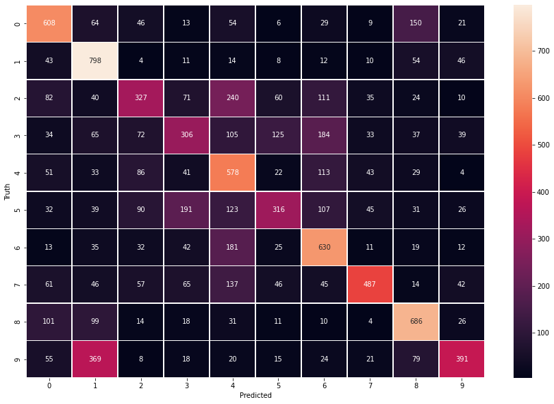

```python
plt.figure(figsize=(15, 10))
sn.heatmap(
    cm,
    annot=True,
    fmt="d",
    linewidth=0.5,
)
plt.xlabel("Predicted")
plt.ylabel("Truth")
```

```python
print(classification_report(y_test_categorical_labels, y_pred_labels))
```

```
              precision    recall  f1-score   support

           0       0.56      0.61      0.58      1000
           1       0.50      0.80      0.62      1000
           2       0.44      0.33      0.38      1000
           3       0.39      0.31      0.34      1000
           4       0.39      0.58      0.47      1000
           5       0.50      0.32      0.39      1000
           6       0.50      0.63      0.56      1000
           7       0.70      0.49      0.57      1000
           8       0.61      0.69      0.65      1000
           9       0.63      0.39      0.48      1000

    accuracy                           0.51     10000
   macro avg       0.52      0.51      0.50     10000
weighted avg       0.52      0.51      0.50     10000
```

### Precision / Recall

[figure not shown]

### F1 Score

[figure not shown]

## Padding and Stride

[figure not shown]

## Data Augmentation to Address Overfitting

[figure not shown]

## Dropout to Address Overfitting

[figure not shown]

## Dealing with Imbalanced Datasets

[figure not shown]

## Transfer Learning

> [TensorFlow Hub](https://tfhub.dev/)  
> [tf2-preview/mobilenet_v2/classification](https://tfhub.dev/google/tf2-preview/mobilenet_v2/classification/4)

[figure not shown]

## tf Dataset - Tensorflow Input Pipeline

[figure not shown]

```python
daily_sales_numbers = [21, 22, -108, 31, -1, 32, 34,31]

tf_dataset = tf.data.Dataset.from_tensor_slices(daily_sales_numbers)
tf_dataset
```

```
<TensorSliceDataset element_spec=TensorSpec(shape=(), dtype=tf.int32, name=None)>
```

```python
tf_dataset = tf_dataset.filter(lambda x: x>0).map(lambda y: y*72).shuffle(2).batch(2)

for sales in tf_dataset.as_numpy_iterator():
    print(sales)
```

```
[1512 2232]
[2304 1584]
[2232 2448]
```

## Prefetch & Cache

[figure not shown]

```python
import time
import tensorflow as tf
```

```python
class FileDataset(tf.data.Dataset):
    def read_file_in_batches(num_samples):
        # Opening the file
        time.sleep(0.03)

        for sample_idx in range(num_samples):
            # Reading data (line, record) from the file
            time.sleep(0.015)

            yield (sample_idx,)

    def __new__(cls, num_samples=3):
        return tf.data.Dataset.from_generator(
            cls.read_file_in_batches,
            output_signature = tf.TensorSpec(shape = (1,), dtype = tf.int64),
            args=(num_samples,)
        )

def benchmark(dataset, num_epochs=2):
    for epoch_num in range(num_epochs):
        for sample in dataset:
            # Performing a training step
            time.sleep(0.01)
```

```python
%%timeit -n1 -r1
benchmark(FileDataset())
```

```
314 ms ± 0 ns per loop (mean ± std. dev. of 1 run, 1 loop each)
```

```python
%%timeit
benchmark(FileDataset().prefetch(1))
```

```
284 ms ± 40.2 ms per loop (mean ± std. dev. of 7 runs, 1 loop each)
```

```python
%%timeit
benchmark(FileDataset().prefetch(tf.data.AUTOTUNE))
```

```
259 ms ± 31.5 ms per loop (mean ± std. dev. of 7 runs, 1 loop each)
```

```python
dataset = tf.data.Dataset.range(5)
dataset = dataset.map(lambda x: x**2)
dataset = dataset.cache("mycache.txt")
# The first time reading through the data will generate the data using
# `range` and `map`.
list(dataset.as_numpy_iterator())
```

[output not shown]

```python
def mapped_function(s):
    # Do some hard pre-processing
    tf.py_function(lambda: time.sleep(0.03), [], ())
    return s
```

## Sliding Window Object Detection

[figure not shown]

## YOLO(You Only Look One)

[figure not shown]

## LTSM (Long Short Term Memory) and GRU (Gated Recurrent Units)

[figure not shown]

## Bidirectional RNN

[figure not shown]

### [BERT (Bidirectional Encoder Representations From Transformers)](https://medium.com/huggingface/introducing-fastbert-a-simple-deep-learning-library-for-bert-models-89ff763ad384)

> [TF2.0 Saved Model (v4)](https://tfhub.dev/tensorflow/bert_en_uncased_L-12_H-768_A-12/4)

[figure not shown]

# Tensorflow Deploymeny

[figure not shown]

-- Memo End --